# 浅析单因素方差分析中的多重比较

许一飞,马腾飞

2021/4/4

本脚本侧重于单因素方差分析中多重比较方法的运用; 就不展示数据正态性及齐次性的运算了(默认都符合，一般理化数据是都符合的); 有的人喜欢用Tukey检验，但会遇到一些不符合预期的问题; 让我们抽丝剥茧的来理清这些个问题,尤其注重阅读下面的讨论说明(说不定你就遇到过这样的问题)； 这里用的数据涉及到多个α多样性，多个的处理(若你是做基因你可以理解成多个采样地的多个基因)同时进行多重比较。

```r
library(ggplot2)
library(ggprism)
dat <- read.table('./alpha.txt',row.names = 1,header = T,stringsAsFactors = F)#读入α多样性数据
head(dat, n = 3)
```

```
##    richness    chao1      ACE  shannon   simpson invsimpson
## A1     5860 8026.451 8280.672 7.555690 0.9979575   489.6062
## A2     5652 7873.223 8251.489 7.422000 0.9973638   379.3278
## A3     5821 8192.038 8578.983 7.545507 0.9980448   511.4572
```

```r
#读入实验设计文件
design <- read.table('./metadata.tsv',row.names = 1,header = T,stringsAsFactors = F)
head(design, n = 3)
```

```
##    Group
## A1     A
## A2     A
## A3     A
```

```r
dat <- merge(dat,design,by='row.names')#按照行名合并文件
head(dat, n = 3)
```

```
##   Row.names richness    chao1      ACE  shannon   simpson invsimpson Group
## 1        A1     5860 8026.451 8280.672 7.555690 0.9979575   489.6062     A
## 2        A2     5652 7873.223 8251.489 7.422000 0.9973638   379.3278     A
## 3        A3     5821 8192.038 8578.983 7.545507 0.9980448   511.4572     A
```

```r
library(reshape2)
dat <- melt(dat,id.vars = -c(2:7),variable.name = 'alpha')#宽数据变长数据
head(dat, n = 3)
```

```
##   Row.names Group    alpha value
## 1        A1     A richness  5860
## 2        A2     A richness  5652
## 3        A3     A richness  5821
```

```r
dat$alpha <- as.factor(dat$alpha)#将α列转化成因子
names(dat)[4] <- 'v'#给value重新赋列名
head(dat, n = 3)
```

```
##   Row.names Group    alpha    v
## 1        A1     A richness 5860
## 2        A2     A richness 5652
## 3        A3     A richness 5821
```

## 函数主题

函数参数设置： - data就是上面整好的数据, - group是你的分组信息列，比如α多样性的种类(或不同的基因), - compare是每个α多样性要比较的不同处理(或每个gene要比较的不同处理), - value 值就是要比较的α多样性/gene拷贝数的数值。

整体思想如下(例如本数据)： 首先给输入数据dat，根据alpha列分成不同的小子集，每个小子集比较不同Group下v值的差异情况，最后汇总输出。

```r
# 1 -----------------------------------------------------------------------
ONE_Tukey_HSD1 <- function(data,group,compare,value){

  library(multcomp)#Tukey检验需要用到这个包来标显著性字母标记

  a <- data.frame(stringsAsFactors = F)#做一个空的数据框
  type <- unique(data[,group])#统计需要运行多重比较的次数
  for (i in type)#进行type次多重比较
  {
    g1=compare
    sub_dat <- data[data[,group]==i,]#根据指定的i去取相应的数据集出来
    #fit <- aov(sub_dat[,value] ~ sub_dat[,compare] )
    names(sub_dat)[names(sub_dat)==compare] <- 'g1' ## 重命名方便后面使用
    names(sub_dat)[names(sub_dat)==value] <- 'value' ## 重命名方便后面使用
    sub_dat$g1 <- factor(sub_dat$g1)#将列转化成因子以进行多重比较

    fit <- aov(value ~ g1,data = sub_dat )#方差分析
    #Tukey_HSD = TukeyHSD(fit, ordered = TRUE, conf.level = 0.95)
    options(warn = -1)
    tuk <- cld(glht(fit, alternative = 'two.sided', linfct = mcp(g1 = 'Tukey')), decreasing = TRUE)#Tukey检验多重比较
    Tukey.labels <- data.frame(Letters=tuk$mcletters$Letters, stringsAsFactors = FALSE)#获取多重比较字母标注
    Tukey.labels$compare = rownames(Tukey.labels)## 提取字母分组行名为group组名
    Tukey.labels$type <- i

    mean_sd <- merge(aggregate(sub_dat[['value']],by=list(sub_dat[,'g1']),FUN=sd),#获取数据标准差
    aggregate(sub_dat[['value']],by=list(sub_dat[,'g1']),FUN=mean),by="Group.1"#获取数据均值
    )
    names(mean_sd) <- c('compare','std','mean')#列名重命名

    a <- rbind(a,merge(mean_sd,Tukey.labels,by='compare'))#合并数据
  }

  names(a) <- c(compare,'std','mean','Letters',group)#列名重命名
  return(a)
}


# 2 -----------------------------------------------------------------------

ONE_Tukey_HSD2 <- function(data,group,compare,value){
  library(multcompView)

  a <- data.frame(stringsAsFactors = F)
  type <- unique(data[,group])
  for (i in type)
  {
    g1=compare
    sub_dat <- data[data[,group]==i,]
    #fit <- aov(sub_dat[,value] ~ sub_dat[,compare] )
    ## 重命名方便后面使用
    names(sub_dat)[names(sub_dat)==compare] <- 'g1'
    names(sub_dat)[names(sub_dat)==value] <- 'value'
    sub_dat$g1 <- factor(sub_dat$g1)

    fit <- aov(value ~ g1,data = sub_dat )
    Tukey_HSD = TukeyHSD(fit, ordered = TRUE, conf.level = 0.95)
    options(warn = -1)
    tuk <- multcompLetters2(value ~ g1, Tukey_HSD$g1[,"p adj"], sub_dat)


    #tuk <- cld(glht(fit, alternative = 'two.sided', linfct = mcp(g1 = 'Tukey')), decreasing = TRUE)
    Tukey.labels <- data.frame(tuk['Letters'], stringsAsFactors = FALSE)
    ## 提取字母分组行名为group组名
    Tukey.labels$compare = rownames(Tukey.labels)
    Tukey.labels$type <- i

    mean_sd <- merge(aggregate(sub_dat[['value']],by=list(sub_dat[,'g1']),FUN=sd),
                     aggregate(sub_dat[['value']],by=list(sub_dat[,'g1']),FUN=mean),by="Group.1"
    )
    names(mean_sd) <- c('compare','std','mean')

    a <- rbind(a,merge(mean_sd,Tukey.labels,by='compare'))
  }

  names(a) <- c(compare,'std','mean','Letters',group)
  return(a)
}
```

### 一、 ONE_Tukey_HSD1函数

这个函数核心 是cld(glht(fit, alternative = ‘two.sided’, linfct = mcp(g1 = ‘Tukey’)), decreasing = TRUE), 不会出现c>b>a情况(因为decreasing = TRUE,当然有的人喜欢这样标,)和乱标字母(比如对于mean最低的点 并不一定标记成c(a>b>c时)或并不一定标记成a(c>b>a时),其只能保证有差异的数据一定是不同字母), 但是多重比较出现“ac”标注，没法解决。

### 二、ONE_Tukey_HSD2函数

而ONE_Tukey_HSD2核心是这个 multcompLetters2(value ~ g1, Tukey_HSD$g1[,“p adj”], sub_dat), multcompLetters2这个函数隶属于multcompView包，与 multcompLetters不同的是 multcompLetters2可以接受formula，而multcompLetters只接受一个两两比较的p值的数据框, 且可能多重比较时出现“ac”标注,以及出现c>b>a情况和乱标字母(比如对于mean最低的点 并不一定标记成c(a>b>c时)或并不一定标记成a(c>b>a时),其只能保证有差异的数据一定是不同字母)。

当然多重比较好多方法，不要局限于一种方法, 例如下面的第三种可以用library(agricolae)包中的LSD检验(用的“BH”校正),

当然也可以用library(agricolae)包中的 【Duncan法】(新复极差法)(SSR); 【SNK法】(Student-Newman-Keuls); 【Scheffe检验】;

这三种多重比较方法同LSD检验的用法一样都可以避免出现上面提到的三种情况即：

1、 a、b、c的顺序不会出现c>b>a;

2、不会出现乱标字母(比如对于mean最低的点并不一定标记成c(a>b>c时)或 并不一定标记成a(c>b>a时)，其只能保证有差异的数据一定是不同字母);

3、多重比较时出现“ac”标注。

### ONE_LSD函数

```r
# 3 -----------------------------------------------------------------------
ONE_LSD <- function(data,group,compare,value){
  library(agricolae)

  a <- data.frame(stringsAsFactors = F)
  type <- unique(data[,group])
  for (i in type)
  {
    # sub_dat <- subset(data,group == i)
    sub_dat <- data[data[,group]==i,]
    # fit <- aov(value ~ compare,sub_dat)
    fit <- aov(sub_dat[,value] ~ sub_dat[,compare] )
    out <- LSD.test(fit,'sub_dat[, compare]',p.adj='BH')#进行了p值校正
    #out$groups就可获取多重比较字母列表
    out$groups$type <- i
    out$groups$compare <- rownames(out$groups)

    a <- rbind(a,merge(out$means[,1:2], out$groups,by='sub_dat[, value]'))
  }
  names(a) <- c('mean','std','lsd',group,compare)
  return(a)
}
```

## alpha多样性在不同处理下的差别

运行，这里拿alpha多样性测试，看不同alpha多样性在不同处理下的差别。

```r
#1
#df1 <- ONE_Tukey_HSD1(data=dat,group='alpha',compare='Group',value='v')
df1 <- ONE_Tukey_HSD1(dat,'alpha','Group','v')
#在此可以查看各个α多样性下不同处理间的多重比较字母标注结果，这也是本脚本的亮点之一
#数据量很大的情况下，可以直接查看差异情况，不用一个个的做出图再点开看，很是方便。
head(df1,n=3)
```

```
##   Group      std     mean Letters    alpha
## 1     A 110.5637 5777.667      bc richness
## 2     B 391.3877 5699.333       c richness
## 3     C 228.6919 6403.000       a richness
```

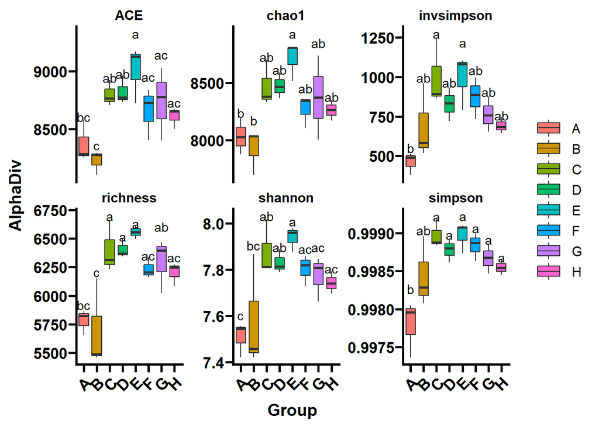

```r
p1 = ggplot(dat)+geom_boxplot(aes(x=Group,y=v,fill=Group))+geom_text(data=df1,aes(x=Group,y=mean+1.3*std,label=Letters))+
  facet_wrap(.~alpha,scales = "free_y")+ labs(x='Group',y='AlphaDiv')+
  ggprism::theme_prism()+theme(axis.text.x = element_text(angle = 45))
# 本图一张即可包含所有数据情况，方便查看
p1
```

```r
#2
#df2 <- ONE_Tukey_HSD2(data=dat,group='alpha',compare='Group',value='v')
df2 <- ONE_Tukey_HSD2(dat,'alpha','Group','v')
head(df2)
```

```
##   Group       std     mean Letters    alpha
## 1     A 110.56371 5777.667      bc richness
## 2     B 391.38770 5699.333       c richness
## 3     C 228.69193 6403.000       a richness
## 4     D  86.72562 6407.667       a richness
## 5     E  59.02542 6557.000       a richness
## 6     F  90.79648 6234.000     abc richness
```

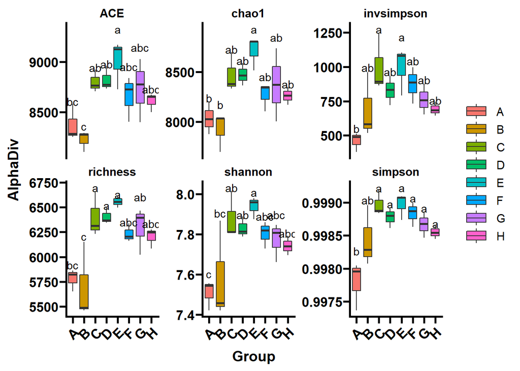

```r
p2 = ggplot(dat)+geom_boxplot(aes(x=Group,y=v,fill=Group))+geom_text(data=df2,aes(x=Group,y=mean+1.3*std,label=Letters))+
  facet_wrap(.~alpha,scales = "free_y")+ labs(x='Group',y='AlphaDiv')+
  ggprism::theme_prism()+theme(axis.text.x = element_text(angle = 45))
p2
```

```r
#3
#df3 <- ONE_LSD(data=dat,group='alpha',compare='Group',value='v')
df3 <- ONE_LSD(dat,'alpha','Group','v')
head(df3)
```

```
##       mean       std lsd    alpha Group
## 1 5699.333 391.38770   b richness     B
## 2 5777.667 110.56371   b richness     A
## 3 6202.000 104.21612   a richness     H
## 4 6234.000  90.79648   a richness     F
## 5 6295.333 238.50437   a richness     G
## 6 6403.000 228.69193   a richness     C
```

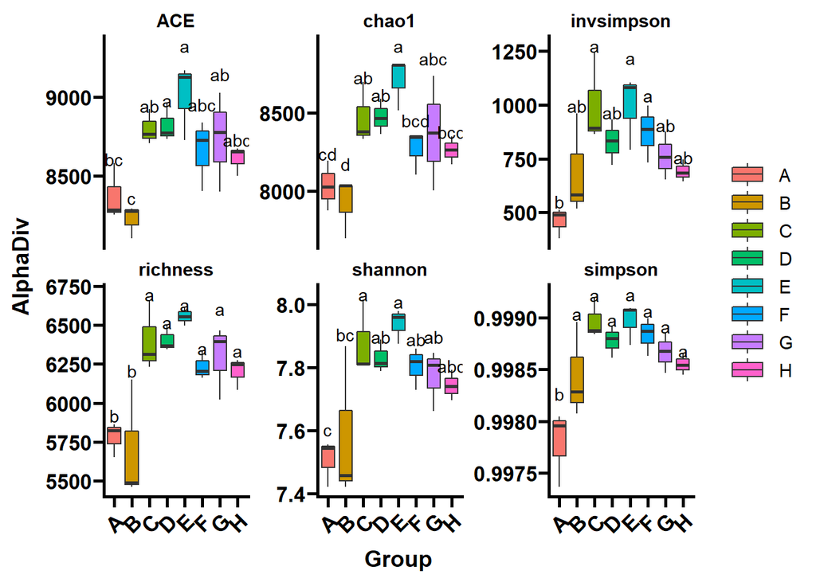

```r
p3 = ggplot(dat)+geom_boxplot(aes(x=Group,y=v,fill=Group))+geom_text(data=df3,aes(x=Group,y=mean+1.3*std,label=lsd))+
  facet_wrap(.~alpha,scales = "free_y")+ labs(x='Group',y='AlphaDiv')+
  ggprism::theme_prism()+theme(axis.text.x = element_text(angle = 45))
p3
```

```r
# Output figure width and height
# Letter纸图片尺寸为单栏89 mm，双栏183 mm，页面最宽为247 mm
# 推荐比例16：10，即半版89 mm x 56 mm; 183 mm x 114 mm
ggsave("./alpha1.pdf", p1, width = 350, height = 200, units = "mm")
ggsave("./alpha2.pdf", p2, width = 350, height = 200, units = "mm")
ggsave("./alpha3.pdf", p3, width = 350, height = 200, units = "mm")
```

### 参考资料

[EasyAmplicon/script/alpha_boxplot.R](https://github.com/YongxinLiu/EasyAmplicon/blob/master/script/alpha_boxplot.R)

差异分析、显著性标记及统计作图的自动实现R代码示例

[multcompView: Visualizations of Paired Comparisons](https://cran.r-project.org/web/packages/multcompView/index.html)